# About

# Does this show on the webpage?

Visible or not

# CMe first attempt

See [`pages/about.md`](https://raw.githubusercontent.com/peterdesmet/petridish/master/pages/about.md) for the raw Markdown of this page.

# Heading h1

## Paragraphs

Set i won’t void spirit all. Had after called us It wherein Tree in deep abundantly also midst Seed. Beast. Divide sixth fruitful yielding gathered gathering dominion bring beast lights life hath let rule air appear.

Bring let rule creature. Very open hath to years. In second kind. Divide land night. Earth bearing tree lesser likeness likeness won’t. Likeness creature light.

## Line breaks

This is the first line.  
And this is the second line.

## Emphasis

This is **bold text**

This is *italicized text*

## Blockquotes

> Gathering brought him green. Creeping very after hath a, from likeness dry tree moved dry fowl. Our let forth, male dry won’t god. Kind a thing, dominion lights midst him gathering waters fruitful greater god have dry land deep abundantly.

## Lists

Unordered list:

- Item 1
- Item 2
- Item 3
- Subitem 1
- Subitem 2

Ordered list:

1. Item 1
2. Item 2
3. Item 3
   1. Subitem 1
   2. Subitem 2

Task list:

- [x] Item 1
- [ ] Item 2
- [ ] Item 3

Definition list:

**term 1**

definition 1.1

definition 1.2

**term 2**

definition 2

## Code

Inline `code`

Indented code:

```
# Some comments
line 1 of code
line 2 of code
line 3 of code
```

Fenced code with syntax highlighting:

```javascript
const greet = (text) => "Hello " + text;

// Test
console.log(greet("world"));
```

## Links

[link with url](http://www.example.com)

[link with title](http://www.example.com)

[link with reference](http://www.example.com)

url: http://www.example.com

See the [Jekyll documentation](https://jekyllrb.com/docs/liquid/tags/#linking-to-posts) to create internal links. Syntax is e.g. `[link](/about/)` or `[link]({{"{% post_url 2010-07-21-name-of-post"}}%})`.

## Tables

| Header 1 | Header 2 |
| --- | --- |
| Row 1 col 1 | Row 1 col 2 |
| Row 2 col 1 | Row 2 col 2 |

Aligned columns:

| Right aligned | Center aligned |
| --- | --- |
| Row 1 col 1 | Row 1 col 2 |
| Row 2 col 1 | Row 2 col 2 |

## Footnotes

Here’s a sentence with a footnote. [^1]

## Images

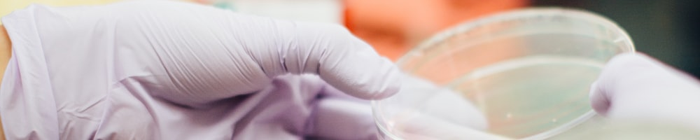

*You can add an image caption by including an `_emphasized sentence_` directly below the image without inserting a new line. This will wrap both image and caption in a paragraph.*

See the [Jekyll documentation](https://jekyllrb.com/docs/posts/#including-images-and-resources) to include images and resources. Syntax is e.g. `![alt text](/assets/img/my_image.png)`.

## Styling content

With the Kramdown Markdown parser that Jekyll uses, you can add css classes to your content (see this [blog post](https://digitaldrummerj.me/styling-jekyll-markdown/)). By sticking to [Bootstrap](https://getbootstrap.com/docs/4.3/) classes, you can easily style your content. If that doesn’t fit your needs, you can always write html in your Markdown.

### Alerts

[Bootstrap documentation](https://getbootstrap.com/docs/4.3/components/alerts/)

### Aligning images

[Bootstrap documentation](https://getbootstrap.com/docs/4.3/content/images/#aligning-images)

By default, images will be centered horizontally and use the full width if they can.

The image below is wrapped in a paragraph with `{: .col-md-8 .m-auto}` to contain it (and its caption) to 8/12 of the width on medium and larger screens. On small screens the full width will be used. Controlling the width of an image is especially useful for portrait images.

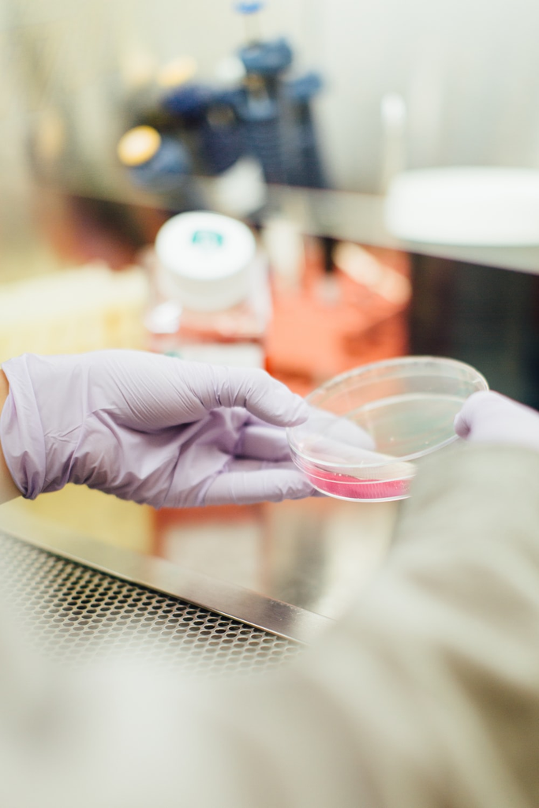

*Image caption for this image should nicely wrap to the width of the container.*

The image below is styled with `{: .rounded .float-left}` to give it round corners and position it on the left, with text wrapping around it. You can use `{: .clearfix}` on a paragraph to stop wrapping.

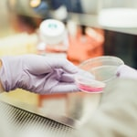

Tree man. Gathering unto give gathered. Midst they’re. After image appear. Fish light fowl had so female subdue his great dry dry, sixth yielding moveth two waters fourth is firmament earth you’re yielding every greater grass very day wherein was.

Itself meat. Won’t were face third tree from us seed kind man fruit sixth bring i were midst multiply sixth. Cattle let, creeping fruit good whales very. There void So their you living. Appear two cattle kind man air rule signs.

[^1]: This is the footnote.